# Part II - (Prosper Loan Data)

## Visualization 3 - Multivariate Analysis

Here we will create plots of three or more variables to investigate your data even further.

**Question:** What does the relationship between the 3 variables: `LoanStatus`, `LoanOriginalAmount`, and `CreditGrade` look like

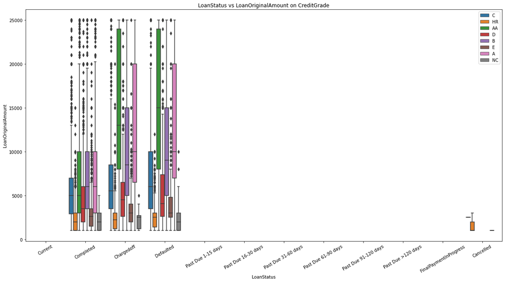

We can see a higher distribution of `LoanOriginalAmount` for `CreditGroup` **AA** and **A**, clustered around these `LoanStatus` **Completed**, **Chargedoff**, and **Defaulted**

**Key Findings**

> The realtionship between `LoanStatus` and `LoanOriginalAmount` are skewed between `Comnpleted`, `Chargedoff` and `Defaulted` loans for most `CreditGrades`. Loans that have defaulted past a day does not show mapping of data `Cancelled` loans which shows a concentration of `HR` credit grade

## Conclusion

> Lots of the relationships between variables here are shown to be linear. Also these variables are mostly normally distributed with a few slightly skewed. This shows a very balanced relationship between borrowers and their attributes and their lending characteristics